# R Notebook

1. Ugbo Chima Onwuka
2. Ajagu Kenneth Chibuzo
3. Onuoha Onyekachi Prince

#Import the CRM data

```r
store.df <- read.csv("http://goo.gl/QPDdMl")
str(store.df)
```

```
'data.frame':   2080 obs. of  10 variables:
 $ storeNum: int  101 101 101 101 101 101 101 101 101 101 ...
 $ Year    : int  1 1 1 1 1 1 1 1 1 1 ...
 $ Week    : int  1 2 3 4 5 6 7 8 9 10 ...
 $ p1sales : int  127 137 156 117 138 115 116 106 116 145 ...
 $ p2sales : int  106 105 97 106 100 127 90 126 94 91 ...
 $ p1price : num  2.29 2.49 2.99 2.99 2.49 2.79 2.99 2.99 2.29 2.49 ...
 $ p2price : num  2.29 2.49 2.99 3.19 2.59 2.49 3.19 2.29 2.29 2.99 ...
 $ p1prom  : int  0 0 1 0 0 0 0 0 0 0 ...
 $ p2prom  : int  0 0 0 0 1 0 0 0 0 0 ...
 $ country : chr  "US" "US" "US" "US" ...
```

#Question 1 #Using aggregate find mean sales of product 1 at each level of p1price and p1prom.

| p1price | p1prom | p1sales |
| --- | --- | --- |
| 2.19 | 0 | 149.1299 |
| 2.29 | 0 | 141.5628 |
| 2.49 | 0 | 129.3780 |
| 2.79 | 0 | 116.3763 |
| 2.99 | 0 | 108.1633 |
| 2.19 | 1 | 196.3902 |
| 2.29 | 1 | 182.6304 |
| 2.49 | 1 | 168.7381 |
| 2.79 | 1 | 154.0000 |
| 2.99 | 1 | 135.9688 |

#Question 2 #Produce a crosstabulation of country vs. p1prom and figure out the % of weeks on promotion for product 1 for each country so that your table allows saying “In country X product 1 was on promotion …% of the weeks). Does any country stand out compared to others?

```r
percentage_table <- prop.table(xtabs(~ country + p1prom, data = store.df), margin = 1) * 100
print(percentage_table)
```

```
       p1prom
country         0         1
     AU 82.692308 17.307692
     BR 87.980769 12.019231
     CN 87.980769 12.019231
     DE 90.384615  9.615385
     GB 92.948718  7.051282
     JP 90.144231  9.855769
     US 91.346154  8.653846
```

GB stands out because it has the highest percentage (92.95%) of observations with p1prom equal to “0,” which suggests that products in GB are less frequently on promotion compared to other countries in the table.

#Question 3 #In data frame store.df create variable p1p2sales that equals the sum of the two products’ sales.

```r
store.df$p1p2sales <- store.df$p1sales + store.df$p2sales
print(store.df$p1p2sales)
```

```
   [1] 233 242 253 223 238 242 206 232 210 236 227 242 186 215 202 222 227 229 210 222 215 225 224 246 212 206
  [27] 234 225 234 244 209 234 197 296 236 250 211 217 235 240 219 260 232 220 208 239 269 215 233 226 226 229
  [53] 220 208 275 225 244 215 194 220 244 204 226 257 215 257 220 249 245 239 251 241 203 245 255 228 223 263
  [79] 216 209 242 235 254 282 208 220 240 202 189 229 236 241 223 241 281 229 214 241 233 260 200 254 260 241
 [105] 236 238 199 249 194 230 206 217 294 217 249 231 231 226 293 219 222 220 199 291 214 227 208 235 253 250
 [131] 231 237 243 230 256 209 214 199 203 228 235 246 225 236 213 248 208 208 205 226 184 220 198 237 241 266
 [157] 188 309 229 220 242 222 300 186 240 242 227 216 228 236 266 236 237 223 263 263 233 235 238 241 221 251
 [183] 226 211 230 273 210 225 228 240 207 253 230 263 237 247 213 227 238 294 255 236 279 216 224 238 252 221
 [209] 216 224 293 209 278 207 211 275 237 224 233 221 216 277 243 198 229 219 244 242 217 219 238 307 247 213
 [235] 228 243 219 305 215 226 260 268 208 222 251 264 254 229 212 267 232 219 296 210 222 212 221 247 268 235
 [261] 203 246 258 218 295 194 222 214 235 286 217 217 216 219 275 211 210 211 258 221 288 212 216 233 229 233
 [287] 304 215 273 206 238 232 218 226 215 286 261 261 255 216 275 251 218 247 252 264 232 237 231 219 246 232
 [313] 230 248 258 228 240 230 232 265 229 198 221 211 216 190 242 230 250 213 229 228 236 227 241 243 231 225
 [339] 206 213 241 220 217 221 244 200 216 207 228 228 208 238 253 220 246 231 197 212 242 226 219 237 285 234
 [365] 208 240 247 239 230 234 224 217 221 235 236 232 245 207 260 203 212 212 222 262 221 269 237 232 282 219
```

[output cut: 25 more lines]

#Question 4 #Using aggregate find total sales of products 1 and 2 for each country. Which country has the highest total sales of these two products?

```r
# Calculate the total sales of p1p2sales for each country
sales_by_country <- aggregate(p1p2sales ~ country, data = store.df, sum)
print(sales_by_country)
```

| country | p1p2sales |
| --- | --- |
| AU | 24478 |
| BR | 49198 |
| CN | 48292 |
| DE | 121139 |
| GB | 72250 |
| JP | 96725 |
| US | 72985 |

```r
# Find the country with the highest total sales of p1p2sales
country_with_highest_sales <- sales_by_country[which.max(sales_by_country$p1p2sales), ]
print(country_with_highest_sales)
```

|  | country | p1p2sales |
| --- | --- | --- |
| 4 | DE | 121139 |

```r
NA
```

The country with the highest sales of the 2 products is DE with 121139 sales

#Question 5 #Using aggregate find total sales of products 1 and 2 for each store. Which store has the highest total sales of these two products? Remember this store’s number (let’s call it XYZ).

```r
# Calculate the total sales of p1sales and p2sales for each store
sales_by_store <- aggregate(cbind(p1sales, p2sales) ~ storeNum, data = store.df, sum)
print(sales_by_store)
```

| storeNum | p1sales | p2sales |
| --- | --- | --- |
| 101 | 13576 | 10433 |
| 102 | 14013 | 10246 |
| 103 | 14148 | 10569 |
| 104 | 13670 | 10323 |
| 105 | 13471 | 10654 |
| 106 | 13915 | 10502 |
| 107 | 13916 | 10129 |
| 108 | 13904 | 10655 |
| 109 | 13681 | 10433 |
| 110 | 13738 | 10103 |

[output cut: 10 more lines]

```r
# Find the store with the highest total sales of products 1 and 2
XYZ <- sales_by_store[which.max(rowSums(sales_by_store[, -1])), ]
print(XYZ)
```

|  | storeNum | p1sales | p2sales |
| --- | --- | --- | --- |
| 13 | 113 | 14328 | 10490 |

```r
NA
```

#Question 6 #Select a subset of store.df containing data only for the store XYZ with the maximum combined sales of products 1 and 2 and name this subset store.XYZ.df, where XYZ is the store’s number.

```r
# Find the store with the highest total sales of products 1 and 2
store_with_highest_sales <- sales_by_store[which.max(rowSums(sales_by_store[, -1])), ]

# Extract the store number with the highest sales
highest_sales_store_number <- store_with_highest_sales$store

# Create a subset of store.df for the store with the highest sales
store.XYZ.df <- store.df[store.df$store == highest_sales_store_number, ]

print(store.XYZ.df)
```

|  | storeNum | Year | Week | p1sales | p2sales | p1price | p2price | p1prom | p2prom | country | p1p2sales |
| --- | --- | --- | --- | --- | --- | --- | --- | --- | --- | --- | --- |
| 1249 | 113 | 1 | 1 | 106 | 90 | 2.29 | 2.29 | 0 | 0 | BR | 196 |
| 1250 | 113 | 1 | 2 | 135 | 142 | 2.99 | 2.99 | 0 | 1 | BR | 277 |
| 1251 | 113 | 1 | 3 | 156 | 65 | 2.29 | 3.19 | 0 | 0 | BR | 221 |
| 1252 | 113 | 1 | 4 | 198 | 60 | 2.19 | 3.19 | 0 | 0 | BR | 258 |
| 1253 | 113 | 1 | 5 | 180 | 74 | 2.29 | 3.19 | 0 | 0 | BR | 254 |
| 1254 | 113 | 1 | 6 | 125 | 91 | 2.79 | 2.99 | 0 | 0 | BR | 216 |
| 1255 | 113 | 1 | 7 | 150 | 71 | 2.29 | 2.99 | 0 | 0 | BR | 221 |
| 1256 | 113 | 1 | 8 | 168 | 80 | 2.29 | 2.49 | 1 | 0 | BR | 248 |
| 1257 | 113 | 1 | 9 | 176 | 72 | 2.19 | 2.99 | 0 | 0 | BR | 248 |
| 1258 | 113 | 1 | 10 | 104 | 169 | 2.99 | 2.49 | 0 | 1 | BR | 273 |

[output cut: 94 more lines]

#Question 7 #Using any functions you know find the % of weeks on which both product 1 and product 2 were on promotion (hint: table/xtabs and prop.table functions may be used). Your command should print that % to the console.

```r
prop.table(xtabs(~store.XYZ.df$p1prom+store.XYZ.df$p2prom)) * 100
```

```
                   store.XYZ.df$p2prom
store.XYZ.df$p1prom         0         1
                  0 71.153846 14.423077
                  1 10.576923  3.846154
```

#Question 8 #Print out Pearson correlations between prices of two products and between sales of two products. Which correlation (between their prices or between their sales) is stronger? Produce Spearman and Kendall correlations, too. Is the conclusion essentially the same?

```r
cor(store.XYZ.df[,c("p1price","p2price")],use = "complete.obs")
```

```
            p1price     p2price
p1price  1.00000000 -0.02504636
p2price -0.02504636  1.00000000
```

```r
cor(store.XYZ.df[,c("p1sales","p2sales")],use = "complete.obs")
```

```
           p1sales    p2sales
p1sales  1.0000000 -0.5590245
p2sales -0.5590245  1.0000000
```

```r
cor(store.XYZ.df[,c("p1price","p2price")],use = "complete.obs",method = "spearman")
```

```
            p1price     p2price
p1price  1.00000000 -0.03604335
p2price -0.03604335  1.00000000
```

```r
cor(store.XYZ.df[,c("p1sales","p2sales")],use = "complete.obs",method = "spearman")
```

```
           p1sales    p2sales
p1sales  1.0000000 -0.5972296
p2sales -0.5972296  1.0000000
```

```r
cor(store.XYZ.df[,c("p1price","p2price")],use = "complete.obs",method = "kendall")
```

```
            p1price     p2price
p1price  1.00000000 -0.02445844
p2price -0.02445844  1.00000000
```

```r
cor(store.XYZ.df[,c("p1sales","p2sales")],use = "complete.obs",method = "kendall")
```

```
           p1sales    p2sales
p1sales  1.0000000 -0.4384624
p2sales -0.4384624  1.0000000
```

#Question 9 #Visualize the associations between all price and sales variables contained in your store.XYZ.df using any scatterplot matrix function you prefer.

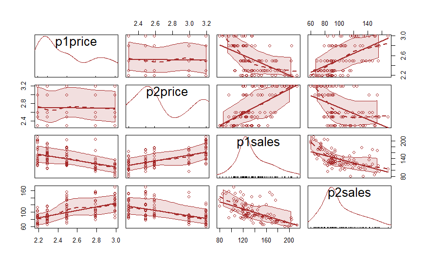

```r
library(car)
scatterplotMatrix(formula =~p1price+p2price+p1sales+p2sales, data = store.XYZ.df, diagonal=list(methods="histogram"), col = 'brown')
```

#Question 10 #Visualize the associations between all price and sales variables contained in your store.XYZ.df using corrplot package. Find in the help file which methods are available other than “ellipse” (option method in corrplot function) and produce corrplots using each of these methods.

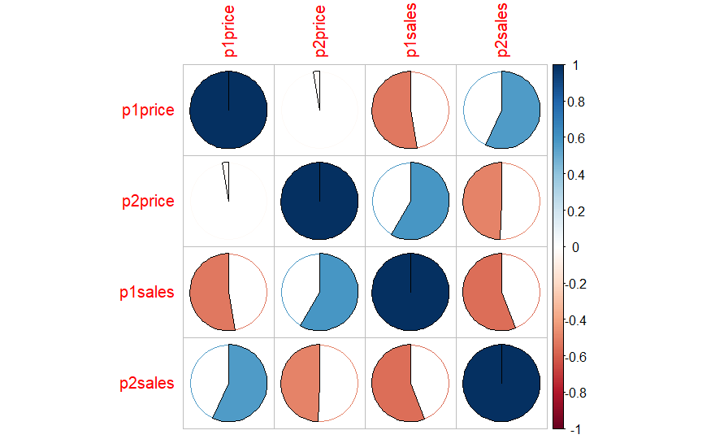

```r
#install.packages("corrplot")
library(corrplot)
corrplot(corr=cor(store.XYZ.df[,c("p1price","p2price","p1sales","p2sales")],use="complete.obs"),method="pie")
```

[figure not shown]

```r
corrplot(corr=cor(store.XYZ.df[,c("p1price","p2price","p1sales","p2sales")],use="complete.obs"),method="shade")
```

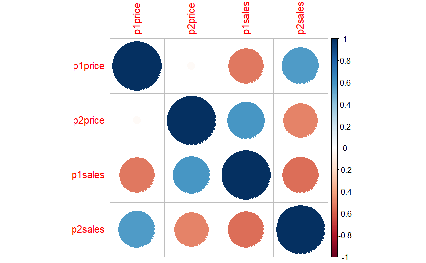

```r
corrplot(corr=cor(store.XYZ.df[,c("p1price","p2price","p1sales","p2sales")],use="complete.obs"),method="circle")
```

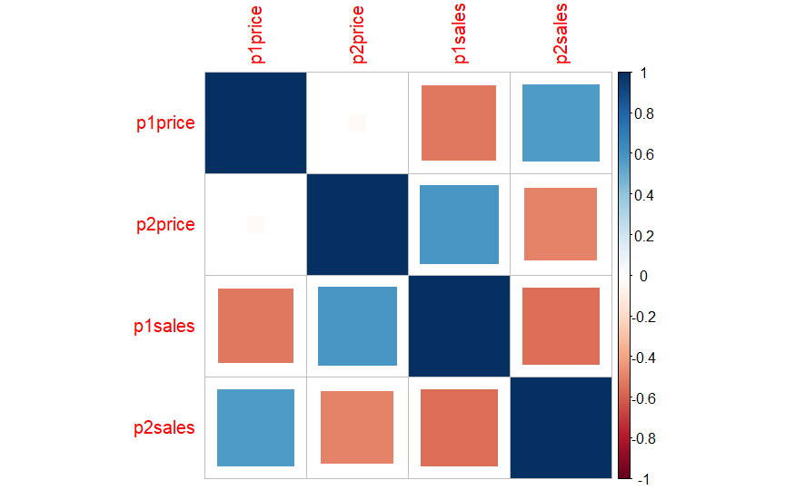

```r
corrplot(corr=cor(store.XYZ.df[,c("p1price","p2price","p1sales","p2sales")],use="complete.obs"),method="square")
```

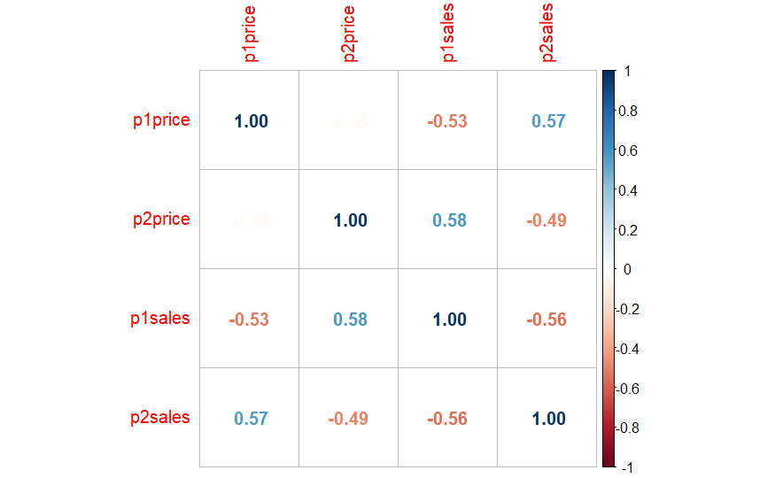

```r
corrplot(corr=cor(store.XYZ.df[,c("p1price","p2price","p1sales","p2sales")],use="complete.obs"),method="number")
```

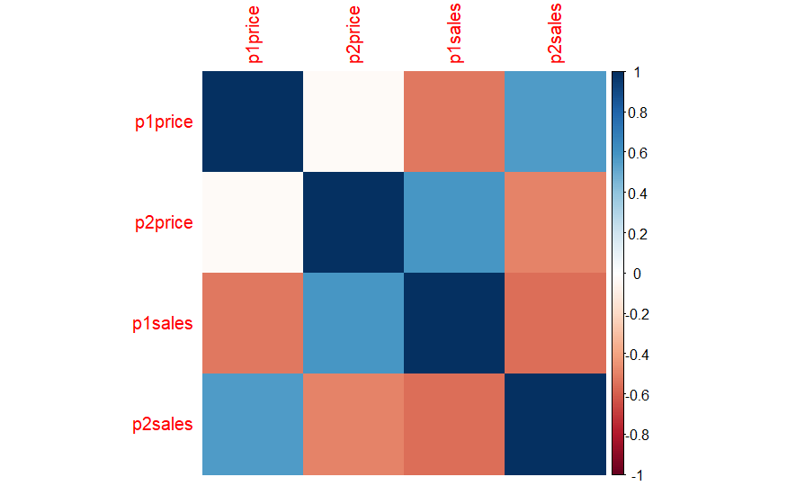

```r
corrplot(corr=cor(store.XYZ.df[,c("p1price","p2price","p1sales","p2sales")],use="complete.obs"),method="color")
```